# R Code for analyses of reproductive trait data for Acanthinucella spirata

Keira Monuki

2026-23-11

Code for the manuscript “Biogeographic variation in reproductive strategy in a range-expanding marine gastropod” in Ecosphere.

## Field Capsule Data Analysis

### Load Packages

Load packages required for downstream analyses.

```r
library(tidyverse)
library(multcomp)
library(nlme)
library(lme4)
library(AICcmodavg)
library(emmeans)
library(car)
library(gridExtra)
```

## Field-collected capsule analysis

Analyses for egg capsules collected in the field from two range-center sites (Cabrillo Beach and Rincon Point) and three range-edge sites (Muir Beach, Dillon Beach, Cape Mendocino). We ran generalized linear mixed models and linear mixed models for egg capsule and hatchling traits.

### Hatchling Size

Import data

```r
hatchling_size <- read.csv("/Users/keiramonuki/Documents/Sanford\ Lab/snail_tank_experiment/field_data/hatchling_size.csv")

head(hatchling_size)
```

```
##         ID Population Aggregation_ID Capsule_ID Hatchling_ID Hatchling_size
## 1 CB1_H1_1         CB              1          1            1          0.647
## 2 CB1_H1_2         CB              1          1            2          0.644
## 3 CB1_H1_3         CB              1          1            3          0.648
## 4 CB1_H1_4         CB              1          1            4          0.651
## 5 CB1_H1_5         CB              1          1            5          0.635
## 6 CB2_H2_1         CB              2          2            1          0.580
```

Check the data distribution, including the mean and standard deviation.

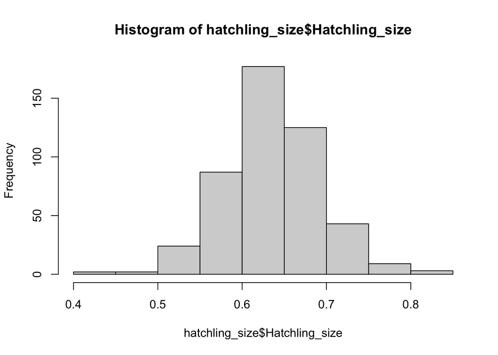

```r
hist(hatchling_size$Hatchling_size)
```

```r
mean(hatchling_size$Hatchling_size)
```

```
## [1] 0.6368008
```

```r
sd(hatchling_size$Hatchling_size)
```

```
## [1] 0.0565757
```

Run a GLMM with a gamma distribution and log link function and check AIC model fit.

```r
hatch_size_gm <-
  glm(Hatchling_size ~ Population + (1 | Aggregation_ID/Capsule_ID), family = Gamma(link = log),data = hatchling_size)

summary(hatch_size_gm)
```

```
##
## Call:
## glm(formula = Hatchling_size ~ Population + (1 | Aggregation_ID/Capsule_ID),
##     family = Gamma(link = log), data = hatchling_size)
##
## Coefficients: (1 not defined because of singularities)
##                                    Estimate Std. Error t value Pr(>|t|)
## (Intercept)                       -0.492229   0.009306 -52.891  < 2e-16 ***
## PopulationCM                       0.070686   0.012035   5.873 8.12e-09 ***
## PopulationDB                       0.083120   0.012631   6.581 1.26e-10 ***
## PopulationMB                       0.015137   0.013623   1.111    0.267
## PopulationRP                       0.015641   0.012279   1.274    0.203
## 1 | Aggregation_ID/Capsule_IDTRUE        NA         NA      NA       NA
## ---
## Signif. codes:  0 '***' 0.001 '**' 0.01 '*' 0.05 '.' 0.1 ' ' 1
##
## (Dispersion parameter for Gamma family taken to be 0.006928863)
##
##     Null deviance: 3.7889  on 471  degrees of freedom
## Residual deviance: 3.2641  on 467  degrees of freedom
## AIC: -1425.5
##
## Number of Fisher Scoring iterations: 4
```

```r
anova(hatch_size_gm)
```

```
## Analysis of Deviance Table
##
## Model: Gamma, link: log
##
## Response: Hatchling_size
##
## Terms added sequentially (first to last)
##
##
##                               Df Deviance Resid. Df Resid. Dev      F    Pr(>F)
## NULL                                            471     3.7889
## Population                     4  0.52479       467     3.2641 18.935 1.925e-14
## 1 | Aggregation_ID/Capsule_ID  0  0.00000       467     3.2641
##
## NULL
## Population                    ***
## 1 | Aggregation_ID/Capsule_ID
## ---
## Signif. codes:  0 '***' 0.001 '**' 0.01 '*' 0.05 '.' 0.1 ' ' 1
```

```r
Anova(hatch_size_gm)
```

```
## Analysis of Deviance Table (Type II tests)
##
## Response: Hatchling_size
##                               LR Chisq Df Pr(>Chisq)
## Population                       75.74  4  1.389e-15 ***
## 1 | Aggregation_ID/Capsule_ID           0
## ---
## Signif. codes:  0 '***' 0.001 '**' 0.01 '*' 0.05 '.' 0.1 ' ' 1
```

```r
AICc(hatch_size_gm)
```

```
## [1] -1425.341
```

```r
AIC(hatch_size_gm)
```

```
## [1] -1425.522
```

Run pairwise comparisons in emmeans using Tukey adjustments.

```r
em <- emmeans(hatch_size_gm, "Population", data = hatchling_size)
contrast(em, "pairwise", adjust = "Tukey")
```

```
##  contrast  estimate     SE  df t.ratio p.value
##  CB - CM  -0.070686 0.0120 467  -5.873 <0.0001
##  CB - DB  -0.083120 0.0126 467  -6.581 <0.0001
##  CB - MB  -0.015137 0.0136 467  -1.111  0.8007
##  CB - RP  -0.015641 0.0123 467  -1.274  0.7075
##  CM - DB  -0.012435 0.0115 467  -1.086  0.8139
##  CM - MB   0.055548 0.0125 467   4.430  0.0001
##  CM - RP   0.055045 0.0111 467   4.976 <0.0001
##  DB - MB   0.067983 0.0131 467   5.185 <0.0001
##  DB - RP   0.067480 0.0117 467   5.763 <0.0001
##  MB - RP  -0.000503 0.0128 467  -0.039  1.0000
##
## Results are given on the log (not the response) scale.
## P value adjustment: tukey method for comparing a family of 5 estimates
```

Plot model residuals

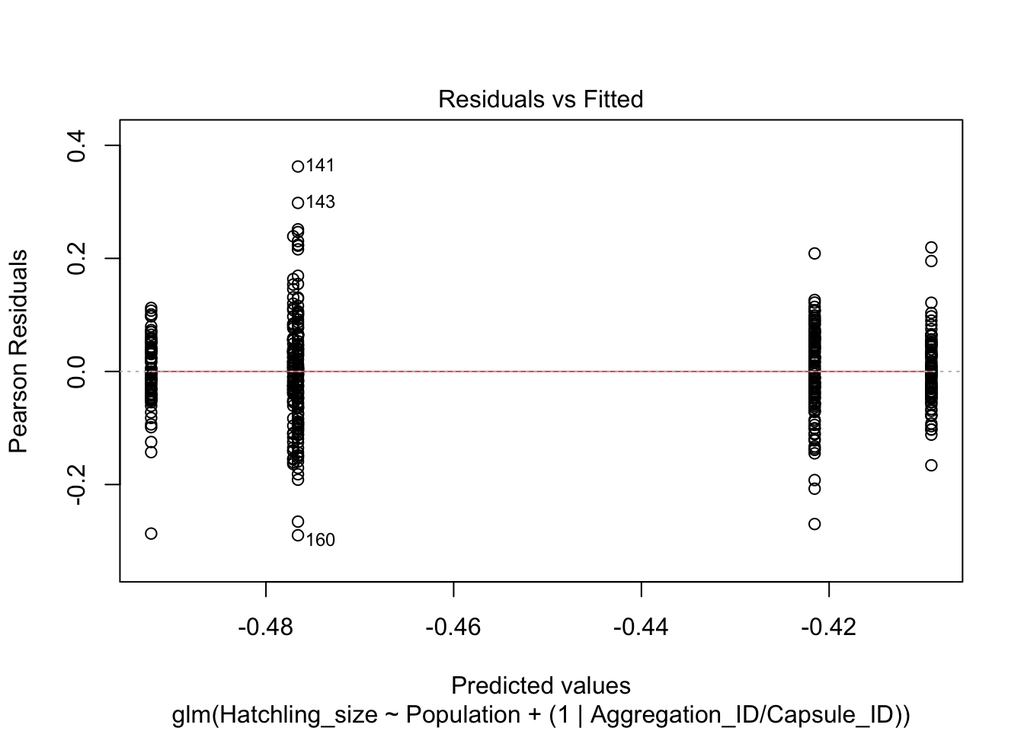

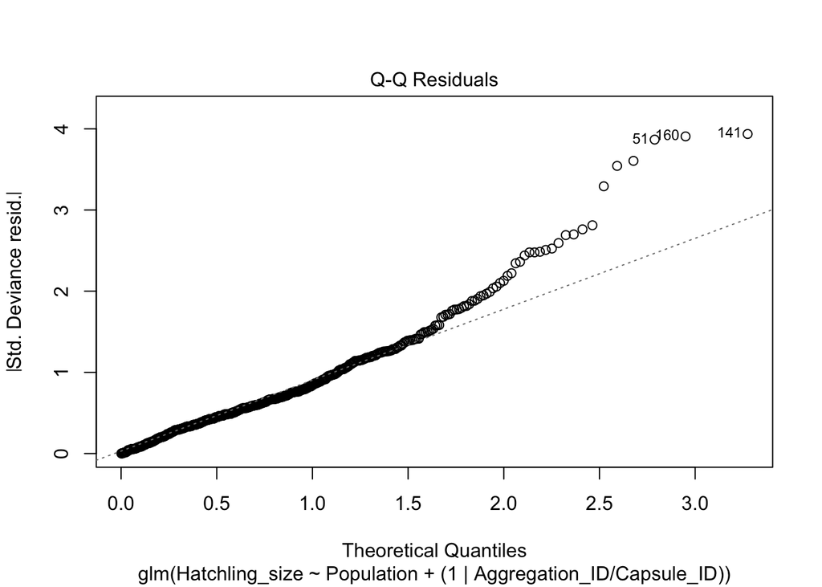

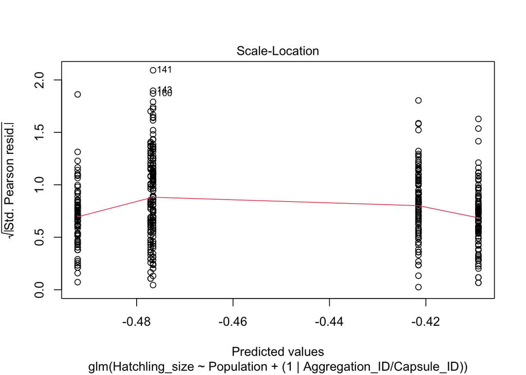

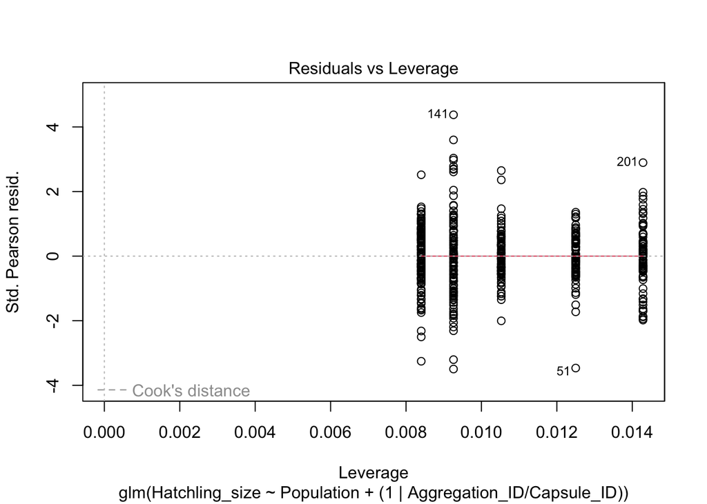

```r
plot(hatch_size_gm)
```

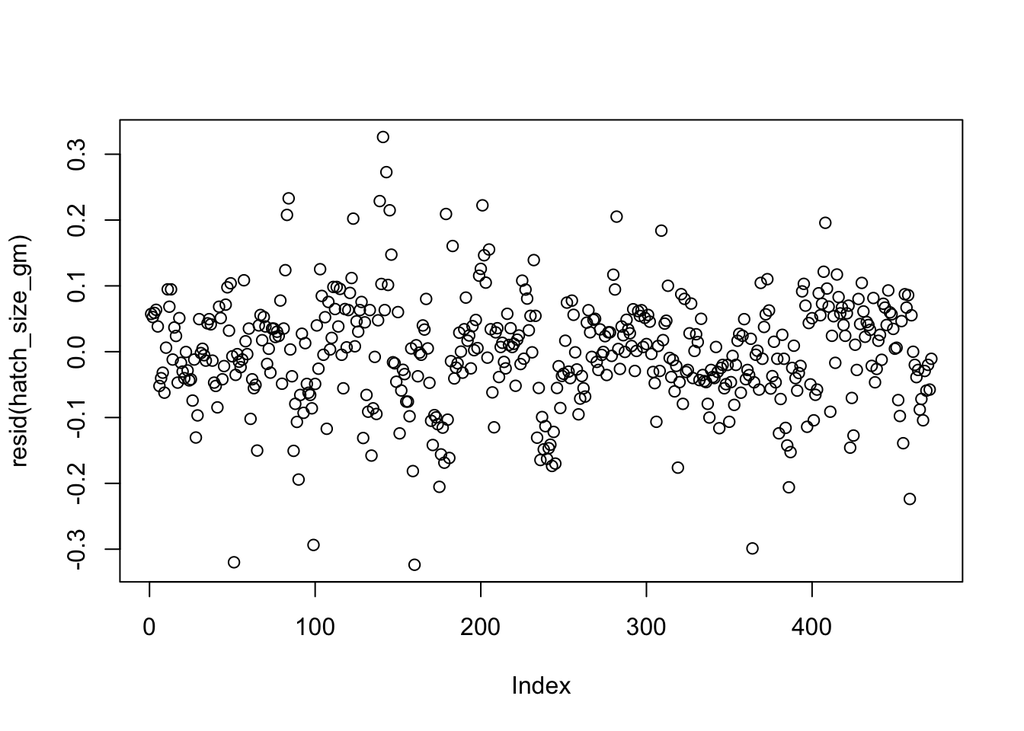

```r
plot(resid(hatch_size_gm))
```

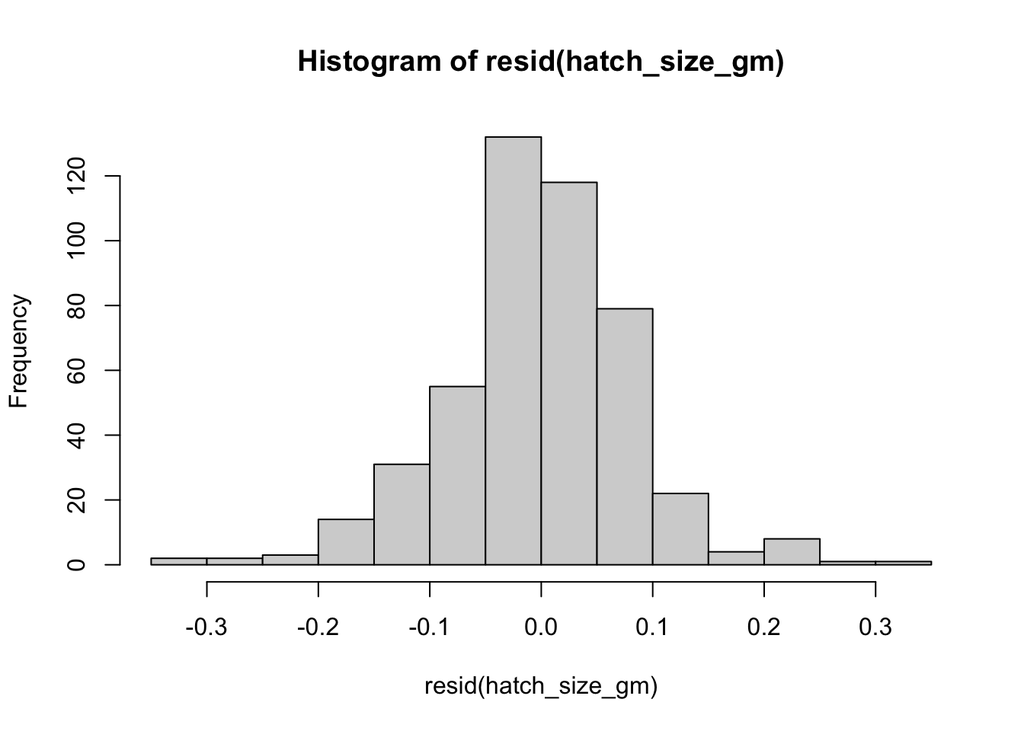

```r
hist(resid(hatch_size_gm))
```

Q-Q plot of residuals

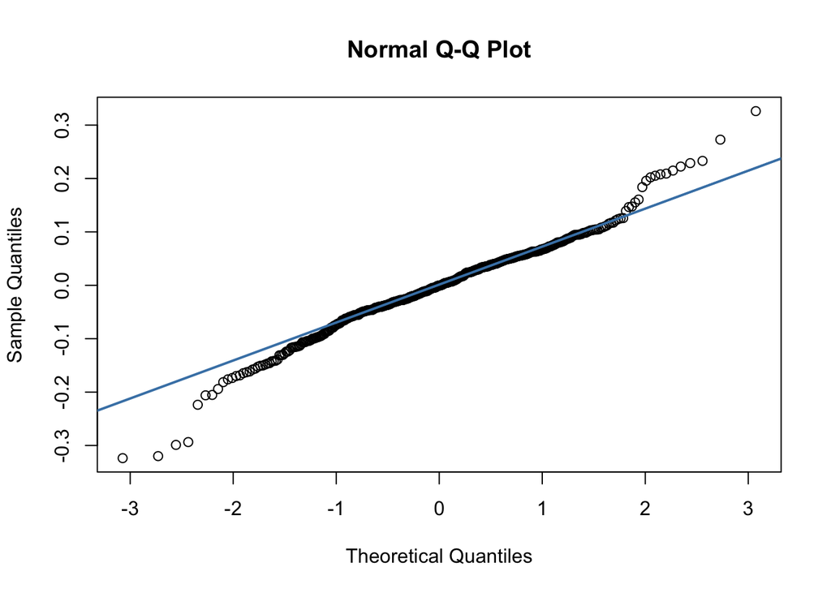

```r
qqnorm(resid(hatch_size_gm))
qqline(resid(hatch_size_gm), col = "steelblue", lwd = 2)
```

Back-transform the model estimates to plot on top of raw data scatter.

```r
emmeans(hatch_size_gm, "Population", type  = "response", data = hatchling_size)
```

```
##  Population response      SE  df lower.CL upper.CL
##  CB            0.611 0.00569 467    0.600    0.623
##  CM            0.656 0.00501 467    0.646    0.666
##  DB            0.664 0.00567 467    0.653    0.675
##  MB            0.621 0.00617 467    0.609    0.633
##  RP            0.621 0.00497 467    0.611    0.631
##
## Confidence level used: 0.95
## Intervals are back-transformed from the log scale
```

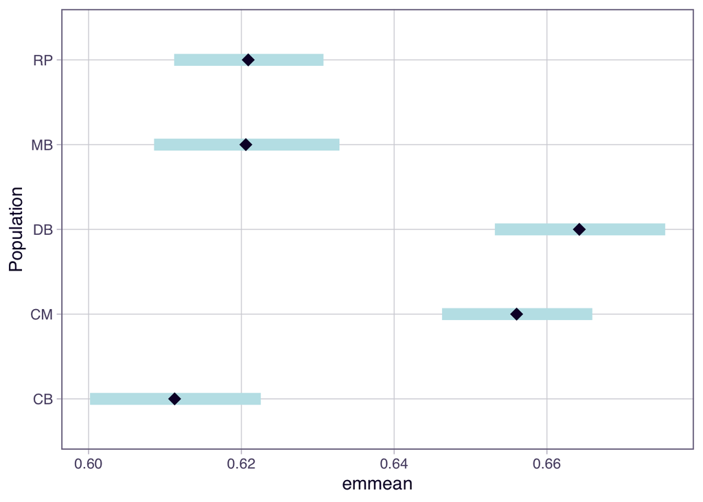

```r
estimates <- emmeans(hatch_size_gm, "Population", type  = "response", data = hatchling_size)

plot(estimates)
```

```r
estimates
```

```
##  Population response      SE  df lower.CL upper.CL
##  CB            0.611 0.00569 467    0.600    0.623
##  CM            0.656 0.00501 467    0.646    0.666
##  DB            0.664 0.00567 467    0.653    0.675
##  MB            0.621 0.00617 467    0.609    0.633
##  RP            0.621 0.00497 467    0.611    0.631
##
## Confidence level used: 0.95
## Intervals are back-transformed from the log scale
```

Create a dataframe of the back-transformed estimates.

```r
site <- c("CB", "CM", "DB", "MB", "RP")

est <- c(0.611, 0.656, 0.664, 0.621, 0.621)


err_high <- c(0.623, 0.666, 0.675, 0.633, 0.631)


err_low <- c(0.600, 0.646, 0.653, 0.609, 0.611)


hatch_size <- data.frame(Population = site, Estimate = est, Error_high = err_high, Error_low = err_low)

hatch_size
```

```
##   Population Estimate Error_high Error_low
## 1         CB    0.611      0.623     0.600
## 2         CM    0.656      0.666     0.646
## 3         DB    0.664      0.675     0.653
## 4         MB    0.621      0.633     0.609
## 5         RP    0.621      0.631     0.611
```

Plot hatchling size across populations.

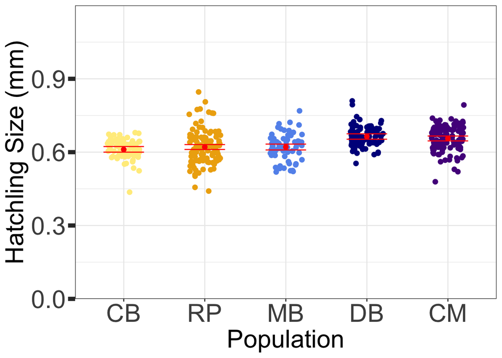

```r
ggplot(hatchling_size, aes(x = Population, y = Hatchling_size, color = Population)) +
  geom_jitter(aes(x = Population, y = Hatchling_size), position=position_jitter(w=0.2), size = 2) +
  scale_color_manual(values = c("lightgoldenrod1", "darkgoldenrod2", "cornflowerblue","darkblue", "purple4")) +
  geom_point(data = hatch_size, aes(x = Population, y = Estimate), size = 2,  color = "red") +
  geom_errorbar(data = hatch_size, aes(x = Population, y = Estimate, ymin = Error_low, ymax = Error_high), color = "red", width = 0.5) +
  theme_bw() +
  theme(legend.position = "none",
        axis.title = element_text(size=25),
        axis.text = element_text(size=25),
        axis.ticks.y = element_line(linewidth = 2),
        axis.ticks.length.y = unit(0.25, "cm")) +
  scale_y_continuous(name = "Hatchling Size (mm)", expand = c(0,0), limits = c(0,1.2)) +
  xlab("Population") -> hatch_size_plot

neworder = c("CB","RP", "MB", "DB", "CM")

hatch_size_plot$data$Population <- factor(hatch_size_plot$data$Population, levels=neworder)

hatch_size_plot
```

### Hatchling Number

Import data

```r
hatchling_number <- read.csv("/Users/keiramonuki/Documents/Sanford\ Lab/snail_tank_experiment/field_data/hatchling_number.csv")

head(hatchling_number)
```

```
##       ID Population Aggregation_ID Temperature Capsule_ID Hatchling_number
## 1 CB1_H1         CB              1           H          1               28
## 2 CB2_H1         CB              2           H          2               18
## 3 CB2_H2         CB              2           H          2               34
## 4 CB3_H1         CB              3           H          1               27
## 5 CB3_H2         CB              3           H          2               44
## 6 CB3_H3         CB              3           H          3               34
```

Check distribution of data, including mean and standard deviation.

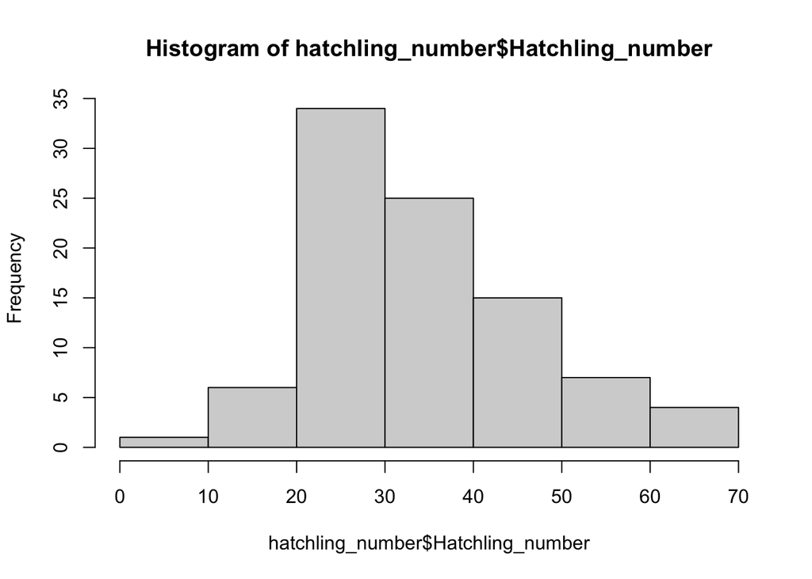

```r
hist(hatchling_number$Hatchling_number)
```

```r
mean(hatchling_number$Hatchling_number)
```

```
## [1] 34.66304
```

```r
sd(hatchling_number$Hatchling_number)
```

```
## [1] 12.03317
```

Run a GLMM with a negative binomial distribution and log link function and calculate AIC.

```r
hatch_num_nb <-
  glm.nb(Hatchling_number ~ Population + (1 | Aggregation_ID), data = hatchling_number)

summary(hatch_num_nb)
```

```
##
## Call:
## glm.nb(formula = Hatchling_number ~ Population + (1 | Aggregation_ID),
##     data = hatchling_number, init.theta = 12.56096083, link = log)
##
## Coefficients: (1 not defined because of singularities)
##                        Estimate Std. Error z value Pr(>|z|)
## (Intercept)             3.52289    0.08012  43.970   <2e-16 ***
## PopulationCM            0.16121    0.10680   1.509    0.131
## PopulationDB            0.01118    0.11021   0.101    0.919
## PopulationMB           -0.06838    0.11985  -0.571    0.568
## PopulationRP           -0.04092    0.10805  -0.379    0.705
## 1 | Aggregation_IDTRUE       NA         NA      NA       NA
## ---
## Signif. codes:  0 '***' 0.001 '**' 0.01 '*' 0.05 '.' 0.1 ' ' 1
##
## (Dispersion parameter for Negative Binomial(12.561) family taken to be 1)
##
##     Null deviance: 98.985  on 91  degrees of freedom
## Residual deviance: 93.150  on 87  degrees of freedom
## AIC: 715.3
##
## Number of Fisher Scoring iterations: 1
##
##
##               Theta:  12.56
##           Std. Err.:  2.52
##
##  2 x log-likelihood:  -703.303
```

```r
anova(hatch_num_nb)
```

```
## Analysis of Deviance Table
##
## Model: Negative Binomial(12.561), link: log
##
## Response: Hatchling_number
##
## Terms added sequentially (first to last)
##
##
##                    Df Deviance Resid. Df Resid. Dev Pr(>Chi)
## NULL                                  91     98.985
## Population          4   5.8352        87     93.150   0.2118
## 1 | Aggregation_ID  0   0.0000        87     93.150
```

```r
Anova(hatch_num_nb)
```

```
## Analysis of Deviance Table (Type II tests)
##
## Response: Hatchling_number
##                    LR Chisq Df Pr(>Chisq)
## Population           5.8352  4     0.2118
## 1 | Aggregation_ID           0
```

```r
AICc(hatch_num_nb)
```

```
## [1] 716.2913
```

```r
AIC(hatch_num_nb)
```

```
## [1] 715.303
```

Plot the model residuals

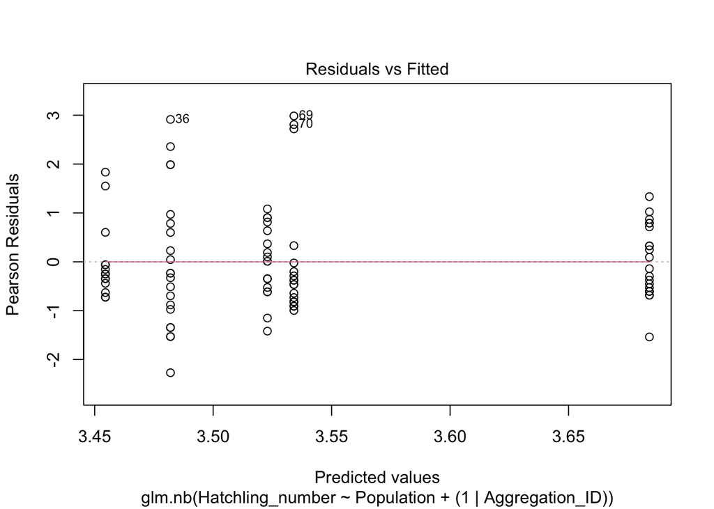

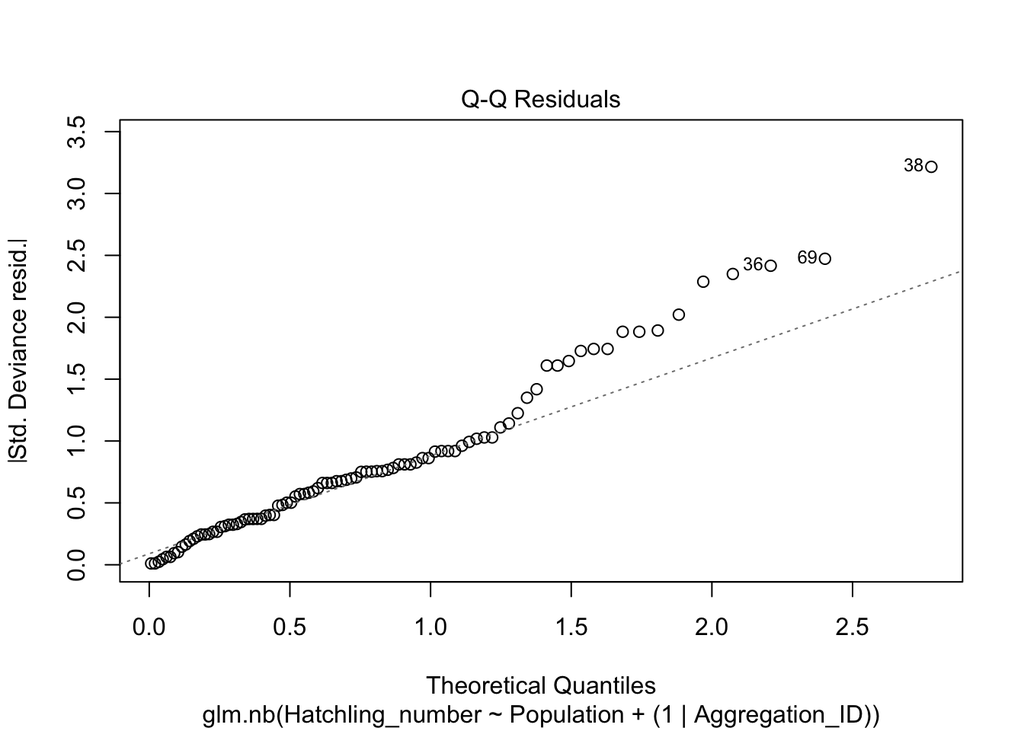

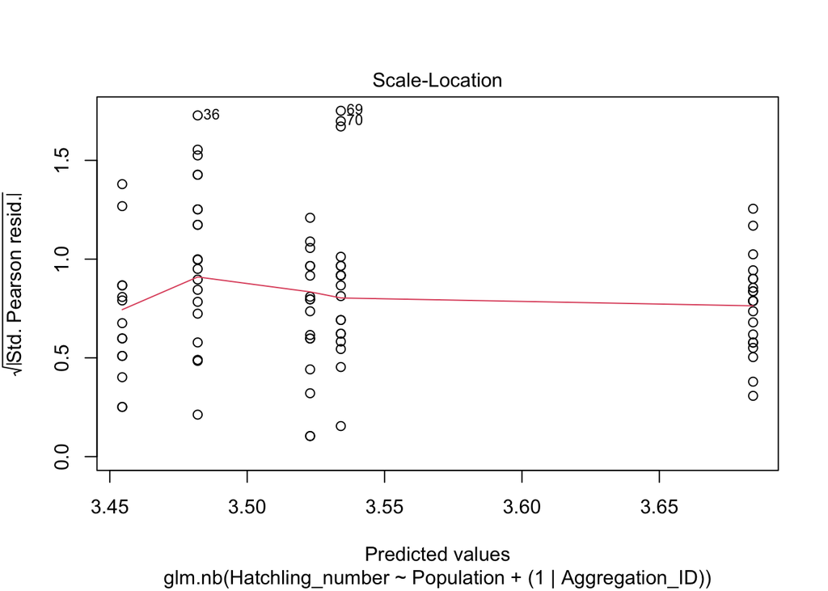

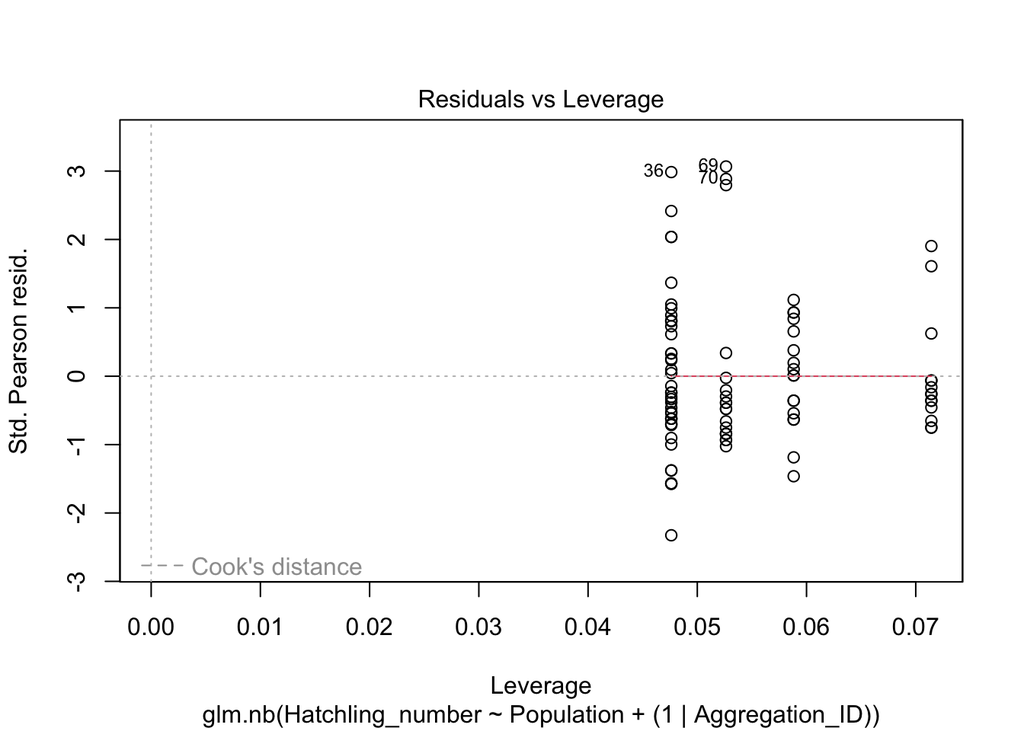

```r
plot(hatch_num_nb)
```

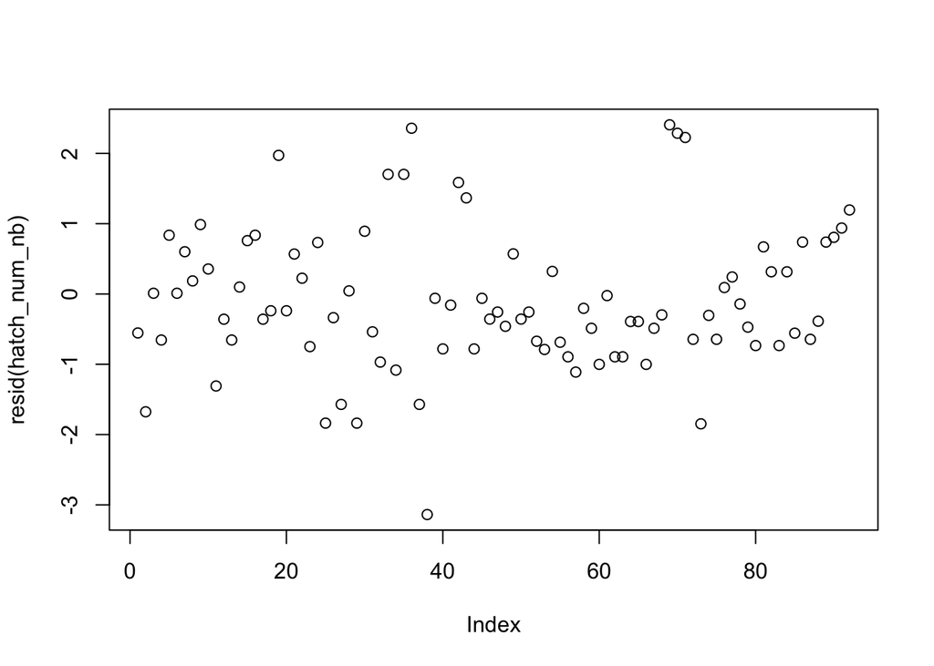

```r
plot(resid(hatch_num_nb))
```

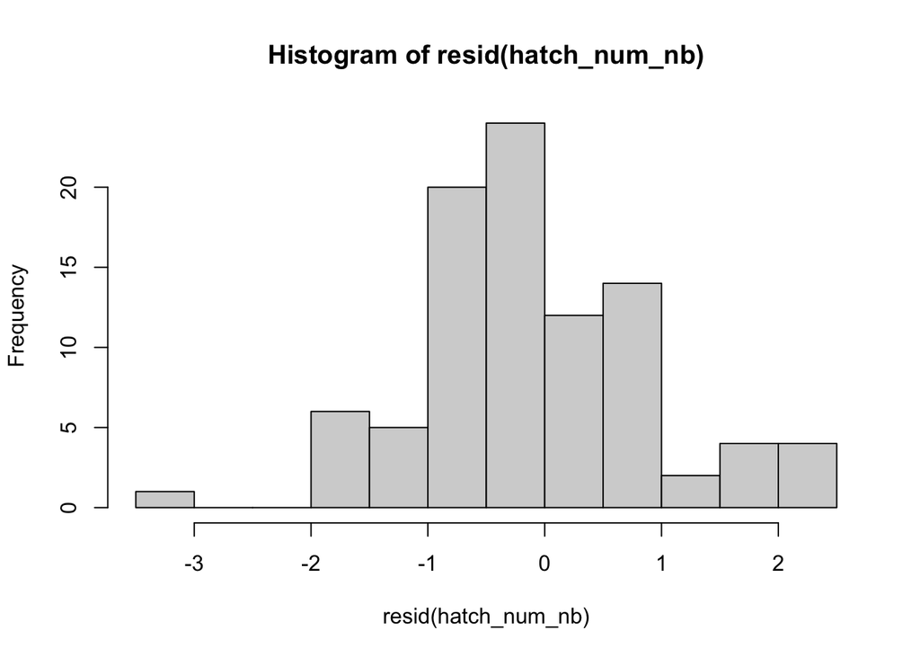

```r
hist(resid(hatch_num_nb))
```

Q-Q plot of model residuals

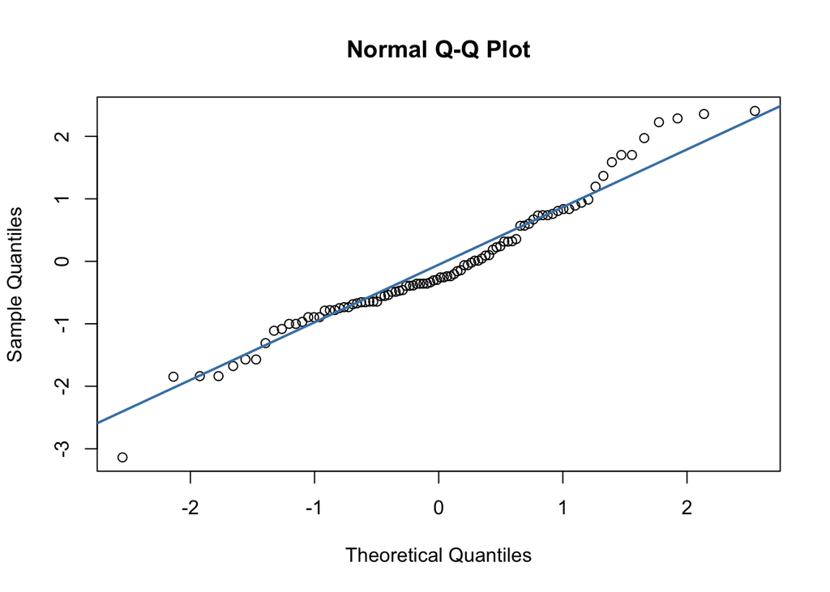

```r
qqnorm(resid(hatch_num_nb))
qqline(resid(hatch_num_nb), col = "steelblue", lwd = 2)
```

Back transform model estimates to plot on top of the raw data scatter

```r
emmeans(hatch_num_nb, "Population", type  = "response", data = hatchling_number)
```

```
##  Population response   SE  df asymp.LCL asymp.UCL
##  CB             33.9 2.71 Inf      29.0      39.6
##  CM             39.8 2.81 Inf      34.7      45.7
##  DB             34.3 2.59 Inf      29.5      39.7
##  MB             31.6 2.82 Inf      26.6      37.7
##  RP             32.5 2.36 Inf      28.2      37.5
##
## Confidence level used: 0.95
## Intervals are back-transformed from the log scale
```

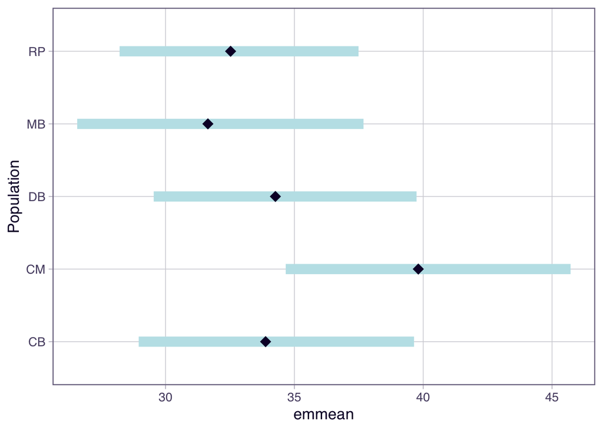

```r
estimates <- emmeans(hatch_num_nb, "Population", type  = "response", data = hatchling_number)

plot(estimates)
```

```r
estimates
```

```
##  Population response   SE  df asymp.LCL asymp.UCL
##  CB             33.9 2.71 Inf      29.0      39.6
##  CM             39.8 2.81 Inf      34.7      45.7
##  DB             34.3 2.59 Inf      29.5      39.7
##  MB             31.6 2.82 Inf      26.6      37.7
##  RP             32.5 2.36 Inf      28.2      37.5
##
## Confidence level used: 0.95
## Intervals are back-transformed from the log scale
```

Create dataframe of back transformed model estimates

```r
site <- c("CB", "CM", "DB", "MB", "RP")

est <- c(33.9, 39.8, 34.3, 31.6, 32.5)


err_high <- c(39.6,45.7, 39.7, 37.7, 37.5)


err_low <- c(29.0, 34.7, 29.5, 26.6, 28.2)


hatch_num <- data.frame(Population = site, Estimate = est, Error_high = err_high, Error_low = err_low)

hatch_num
```

```
##   Population Estimate Error_high Error_low
## 1         CB     33.9       39.6      29.0
## 2         CM     39.8       45.7      34.7
## 3         DB     34.3       39.7      29.5
## 4         MB     31.6       37.7      26.6
## 5         RP     32.5       37.5      28.2
```

Plot hatchling number across populations

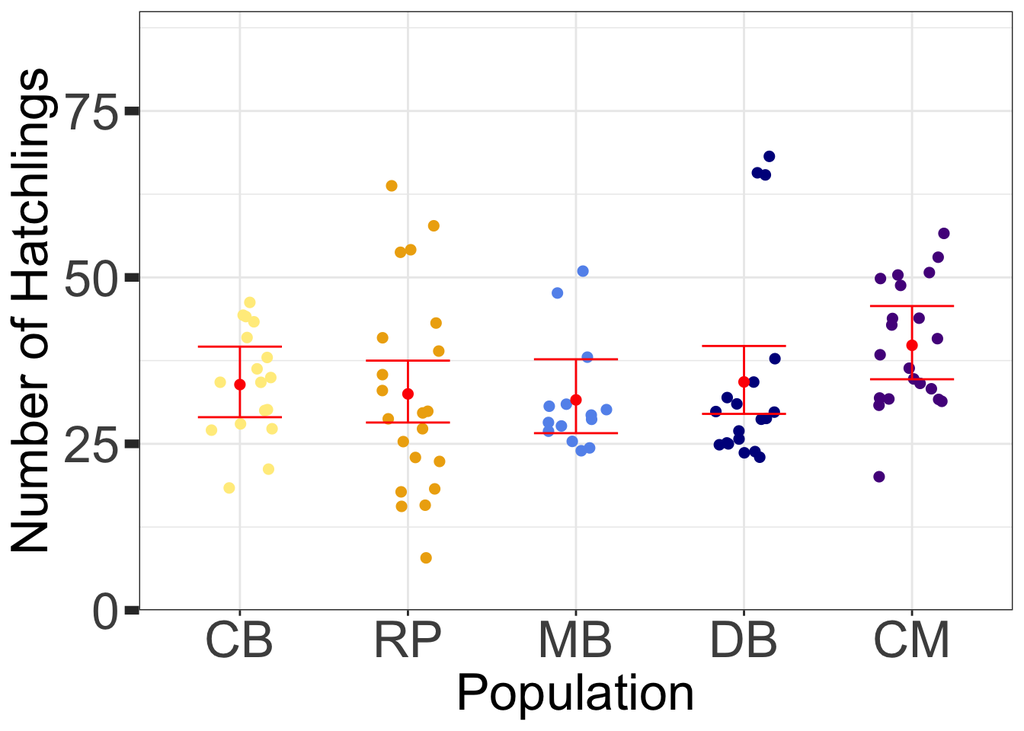

```r
ggplot(hatchling_number, aes(x = Population, y = Hatchling_number, color = Population)) +
  geom_jitter(aes(x = Population, y = Hatchling_number), position=position_jitter(w=0.2), size = 2) +
  scale_color_manual(values = c("lightgoldenrod1", "darkgoldenrod2", "cornflowerblue","darkblue", "purple4")) +
  geom_point(data = hatch_num, aes(x = Population, y = Estimate), size = 2,  color = "red") +
  geom_errorbar(data = hatch_num, aes(x = Population, y = Estimate, ymin = Error_low, ymax = Error_high), color = "red", width = 0.5) +
  theme_bw() +
  theme(legend.position = "none",
        axis.title = element_text(size=25),
        axis.text = element_text(size=25),
        axis.ticks.y = element_line(linewidth = 2),
        axis.ticks.length.y = unit(0.25, "cm")) +
  scale_y_continuous(name = "Number of Hatchlings", expand = c(0,0), limits = c(0,90)) +
  xlab("Population") -> hatch_num_plot


hatch_num_plot$data$Population <- factor(hatch_num_plot$data$Population, levels=neworder)

hatch_num_plot
```

### Embryo Number

Import data

```r
embryo_number <- read.csv("/Users/keiramonuki/Documents/Sanford\ Lab/snail_tank_experiment/field_data/embryo_number.csv")

head(embryo_number)
```

```
##      ID Population Aggregation_ID Capsule_ID Capsule_Length Number_embryos
## 1 CB1_5         CB              1          5          4.248             27
## 2 CB2_2         CB              2          2          3.701             31
## 3 CB2_3         CB              2          3          4.718             32
## 4 CB3_1         CB              3          1          4.109             28
## 5 CB3_2         CB              3          2          3.598             27
## 6 CB4_1         CB              4          1          4.519             44
##   Embryo_size
## 1       0.296
## 2       0.341
## 3       0.374
## 4       0.339
## 5       0.245
## 6       0.374
```

Check distribution of raw data, including mean and standard deviation

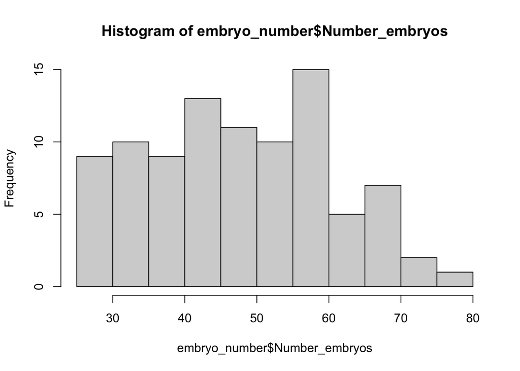

```r
hist(embryo_number$Number_embryos)
```

```r
mean(embryo_number$Number_embryos)
```

```
## [1] 48
```

```r
sd(embryo_number$Number_embryos)
```

```
## [1] 13.01394
```

Run a GLMM with a negative binomial distribution and a log link function

```r
embryo_num_nb <-
  glm.nb(Number_embryos ~ Population + (1 | Aggregation_ID), data = embryo_number)

summary(embryo_num_nb)
```

```
##
## Call:
## glm.nb(formula = Number_embryos ~ Population + (1 | Aggregation_ID),
##     data = embryo_number, init.theta = 38.41931847, link = log)
##
## Coefficients: (1 not defined because of singularities)
##                        Estimate Std. Error z value Pr(>|z|)
## (Intercept)             3.52636    0.06530  53.999  < 2e-16 ***
## PopulationCM            0.40457    0.07962   5.081 3.75e-07 ***
## PopulationDB            0.48097    0.07723   6.227 4.74e-10 ***
## PopulationMB            0.38293    0.07975   4.802 1.57e-06 ***
## PopulationRP            0.06331    0.10111   0.626    0.531
## 1 | Aggregation_IDTRUE       NA         NA      NA       NA
## ---
## Signif. codes:  0 '***' 0.001 '**' 0.01 '*' 0.05 '.' 0.1 ' ' 1
##
## (Dispersion parameter for Negative Binomial(38.4193) family taken to be 1)
##
##     Null deviance: 146.325  on 91  degrees of freedom
## Residual deviance:  91.694  on 87  degrees of freedom
## AIC: 699.52
##
## Number of Fisher Scoring iterations: 1
##
##
##               Theta:  38.4
##           Std. Err.:  10.2
##
##  2 x log-likelihood:  -687.524
```

```r
anova(embryo_num_nb)
```

```
## Analysis of Deviance Table
##
## Model: Negative Binomial(38.4193), link: log
##
## Response: Number_embryos
##
## Terms added sequentially (first to last)
##
##
##                    Df Deviance Resid. Df Resid. Dev  Pr(>Chi)
## NULL                                  91    146.325
## Population          4    54.63        87     91.694 3.883e-11 ***
## 1 | Aggregation_ID  0     0.00        87     91.694
## ---
## Signif. codes:  0 '***' 0.001 '**' 0.01 '*' 0.05 '.' 0.1 ' ' 1
```

```r
Anova(embryo_num_nb)
```

```
## Analysis of Deviance Table (Type II tests)
##
## Response: Number_embryos
##                    LR Chisq Df Pr(>Chisq)
## Population            54.63  4  3.883e-11 ***
## 1 | Aggregation_ID           0
## ---
## Signif. codes:  0 '***' 0.001 '**' 0.01 '*' 0.05 '.' 0.1 ' ' 1
```

```r
AICc(embryo_num_nb)
```

```
## [1] 700.5119
```

```r
AIC(embryo_num_nb)
```

```
## [1] 699.5236
```

Run pairwise comparisons in emmeans with Tukey adjustments

```r
em <- emmeans(embryo_num_nb, "Population", data = embryo_number)
contrast(em, "pairwise", adjust = "Tukey")
```

```
##  contrast estimate     SE  df z.ratio p.value
##  CB - CM   -0.4046 0.0796 Inf  -5.081 <0.0001
##  CB - DB   -0.4810 0.0772 Inf  -6.227 <0.0001
##  CB - MB   -0.3829 0.0797 Inf  -4.802 <0.0001
##  CB - RP   -0.0633 0.1010 Inf  -0.626  0.9709
##  CM - DB   -0.0764 0.0614 Inf  -1.243  0.7258
##  CM - MB    0.0216 0.0646 Inf   0.335  0.9973
##  CM - RP    0.3413 0.0896 Inf   3.807  0.0013
##  DB - MB    0.0980 0.0616 Inf   1.591  0.5028
##  DB - RP    0.4177 0.0875 Inf   4.772 <0.0001
##  MB - RP    0.3196 0.0897 Inf   3.561  0.0034
##
## Results are given on the log (not the response) scale.
## P value adjustment: tukey method for comparing a family of 5 estimates
```

Plot mode residuals to assess model fit

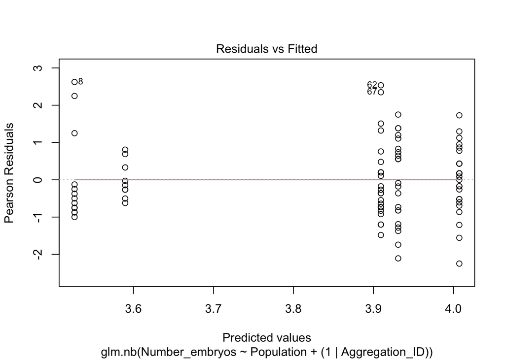

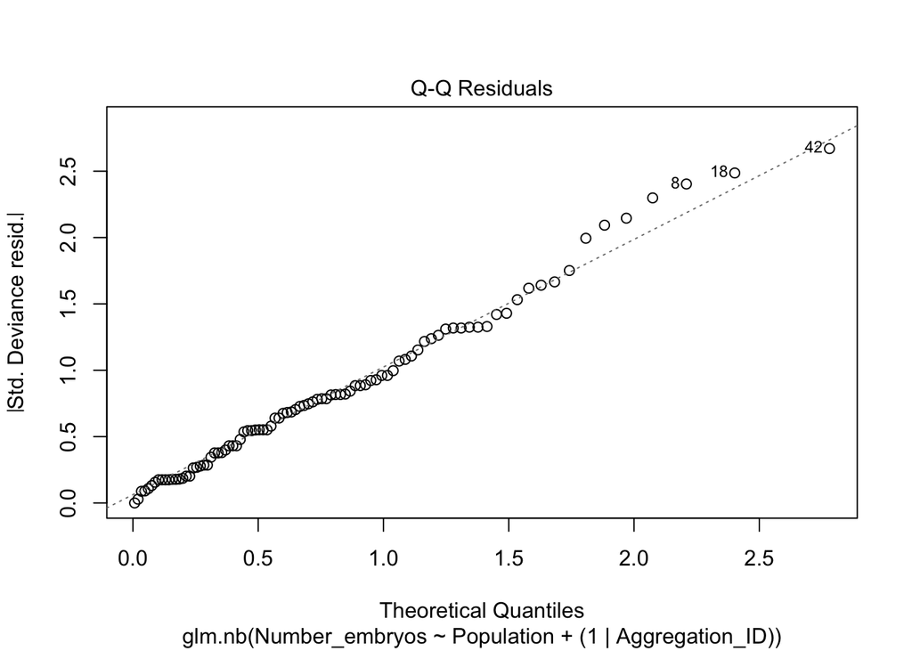

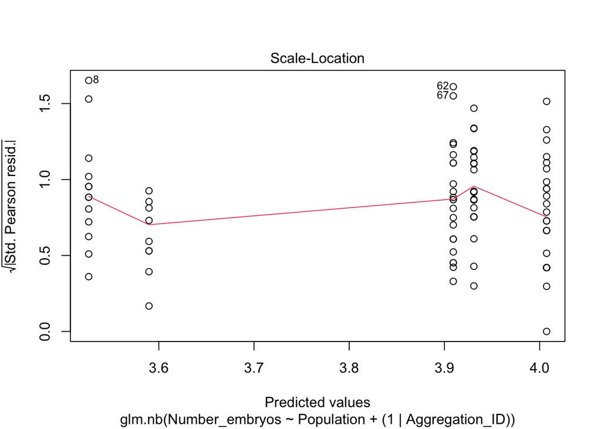

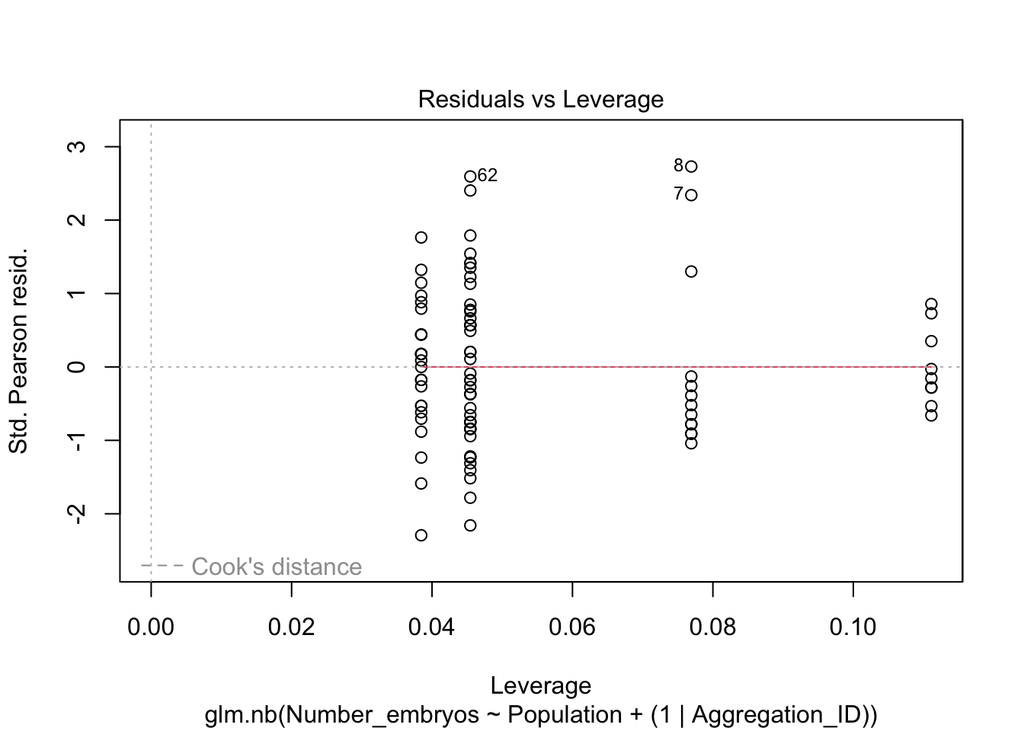

```r
plot(embryo_num_nb)
```

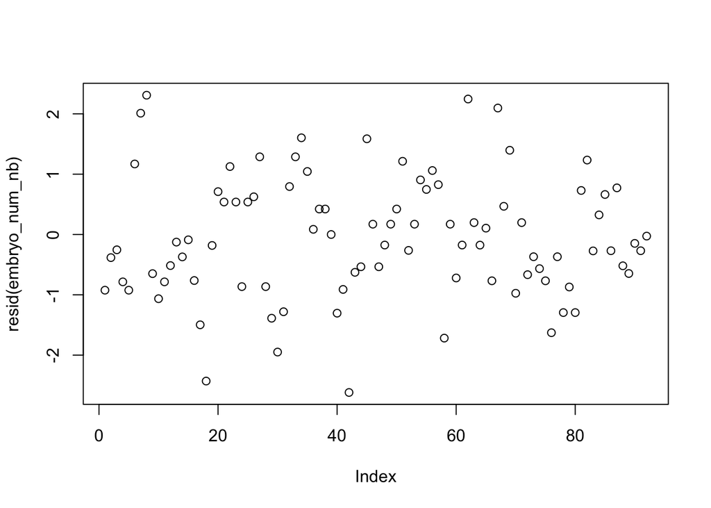

```r
plot(resid(embryo_num_nb))
```

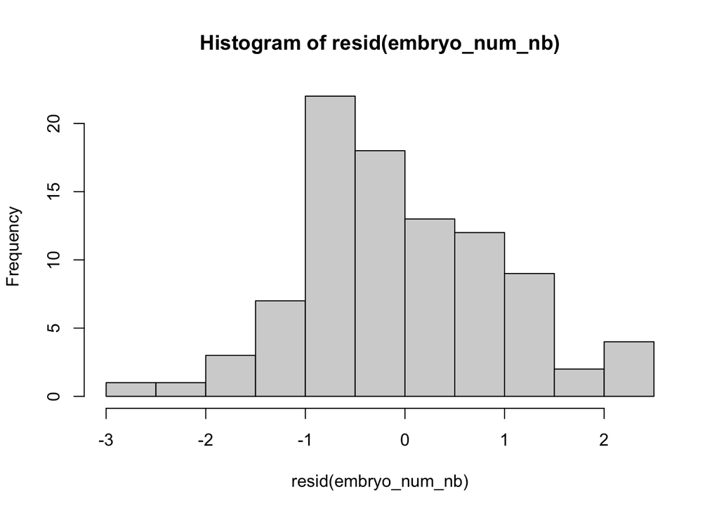

```r
hist(resid(embryo_num_nb))
```

Q-Q plot of model residuals

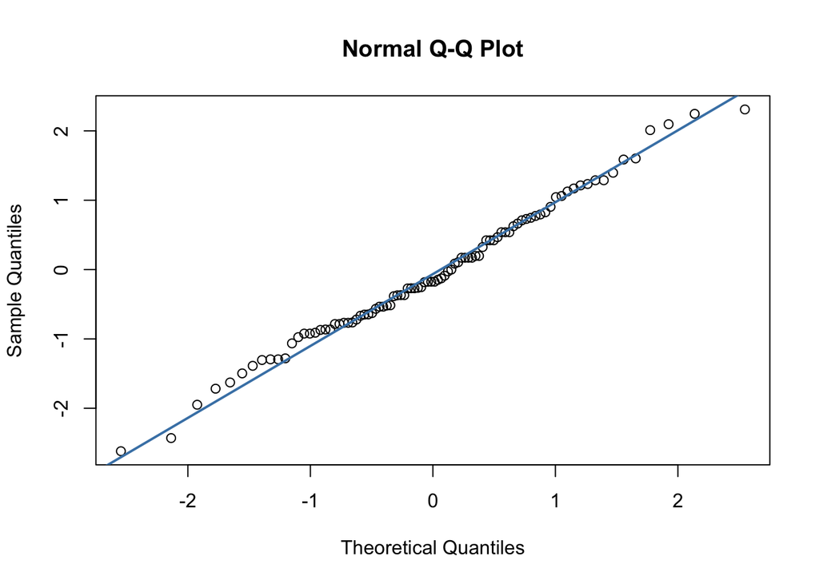

```r
qqnorm(resid(embryo_num_nb))
qqline(resid(embryo_num_nb), col = "steelblue", lwd = 2)
```

Back-transform model estimates to plot on top of the raw data scatter

```r
emmeans(embryo_num_nb, "Population", type  = "response", data = embryo_number)
```

```
##  Population response   SE  df asymp.LCL asymp.UCL
##  CB             34.0 2.22 Inf      29.9      38.6
##  CM             51.0 2.32 Inf      46.6      55.7
##  DB             55.0 2.27 Inf      50.7      59.6
##  MB             49.9 2.28 Inf      45.6      54.5
##  RP             36.2 2.80 Inf      31.1      42.1
##
## Confidence level used: 0.95
## Intervals are back-transformed from the log scale
```

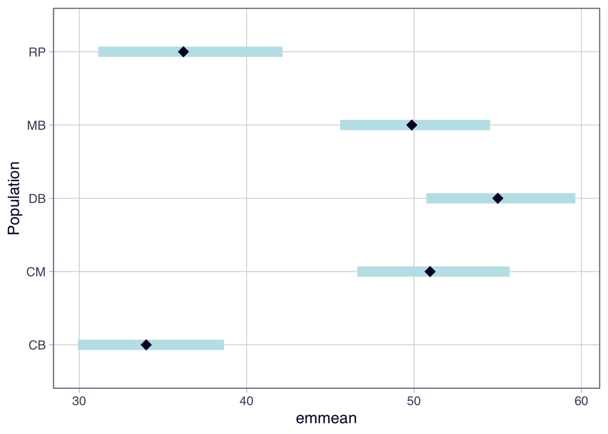

```r
estimates <- emmeans(embryo_num_nb, "Population", type  = "response", data = embryo_number)

plot(estimates)
```

```r
estimates
```

```
##  Population response   SE  df asymp.LCL asymp.UCL
##  CB             34.0 2.22 Inf      29.9      38.6
##  CM             51.0 2.32 Inf      46.6      55.7
##  DB             55.0 2.27 Inf      50.7      59.6
##  MB             49.9 2.28 Inf      45.6      54.5
##  RP             36.2 2.80 Inf      31.1      42.1
##
## Confidence level used: 0.95
## Intervals are back-transformed from the log scale
```

Create data frame of back-transformed estimates

```r
site <- c("CB", "CM", "DB", "MB", "RP")

est <- c(34.0, 51.0, 55.0, 49.9, 36.2)


err_high <- c(38.6, 55.7, 59.6, 54.5, 42.1)


err_low <- c(29.9, 46.6, 50.7, 45.6, 31.1)


emb_num <- data.frame(Population = site, Estimate = est, Error_high = err_high, Error_low = err_low)

emb_num
```

```
##   Population Estimate Error_high Error_low
## 1         CB     34.0       38.6      29.9
## 2         CM     51.0       55.7      46.6
## 3         DB     55.0       59.6      50.7
## 4         MB     49.9       54.5      45.6
## 5         RP     36.2       42.1      31.1
```

Plot number of embryos across populations

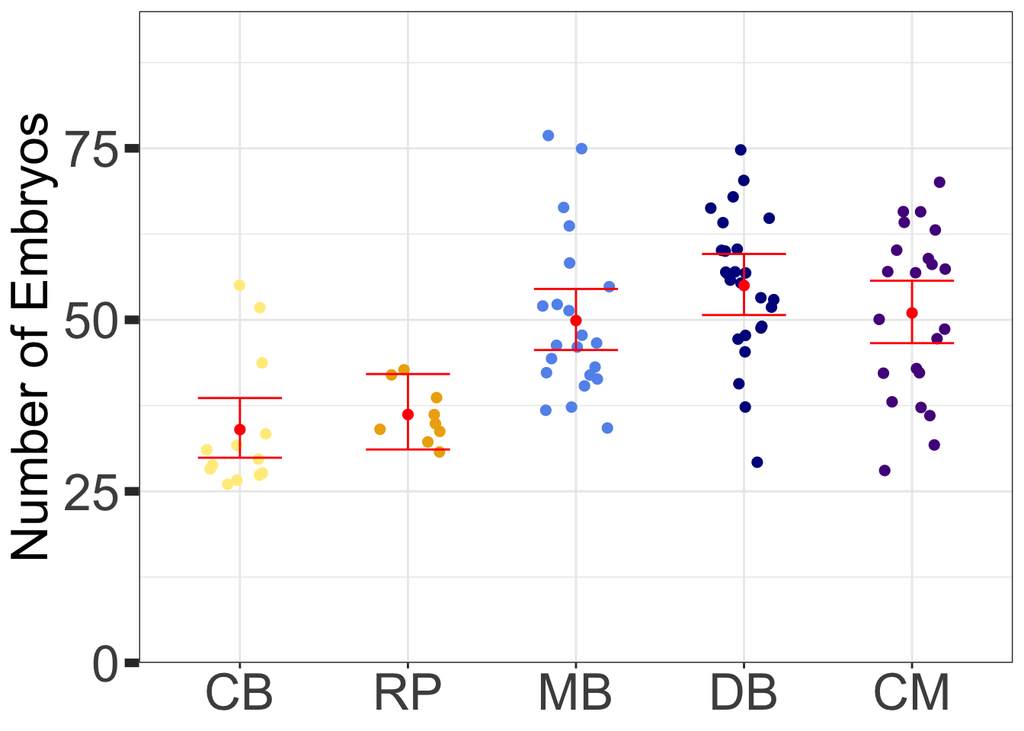

```r
ggplot(embryo_number, aes(x = Population, y = Number_embryos, color = Population)) +
  geom_jitter(aes(x = Population, y = Number_embryos), position=position_jitter(w=0.2), size = 2) +
  scale_color_manual(values = c("lightgoldenrod1", "darkgoldenrod2", "cornflowerblue","darkblue", "purple4")) +
  geom_point(data = emb_num, aes(x = Population, y = Estimate), size = 2,  color = "red") +
  geom_errorbar(data = emb_num, aes(x = Population, y = Estimate, ymin = Error_low, ymax = Error_high), color = "red", width = 0.5) +
  theme_bw() +
  theme(legend.position = "none",
        axis.title.x = element_blank(),
        axis.title.y = element_text(size=25),
        axis.text = element_text(size=25),
        axis.ticks.y = element_line(linewidth = 2),
        axis.ticks.length.y = unit(0.25, "cm")) +
  scale_y_continuous(name = "Number of Embryos", expand = c(0,0), limits = c(0,95)) -> emb_num_plot

emb_num_plot$data$Population <- factor(emb_num_plot$data$Population, levels=neworder)

emb_num_plot
```

### Embryo size

Import data

```r
embryo_size <- read.csv("/Users/keiramonuki/Documents/Sanford\ Lab/snail_tank_experiment/field_data/embryo_size.csv")

head(embryo_size)
```

```
##      ID Population Aggregation_ID Capsule_ID Capsule_Length Number_embryos
## 1 CB1_5         CB              1          5          4.248             27
## 2 CB1_5         CB              1          5          4.248             27
## 3 CB1_5         CB              1          5          4.248             27
## 4 CB1_5         CB              1          5          4.248             27
## 5 CB1_5         CB              1          5          4.248             27
## 6 CB2_1         CB              2          1          4.308             17
##   Embryo_size
## 1       0.296
## 2       0.311
## 3       0.308
## 4       0.279
## 5       0.291
## 6       0.354
```

Check the distribution of the raw data, including mean and standard deviation

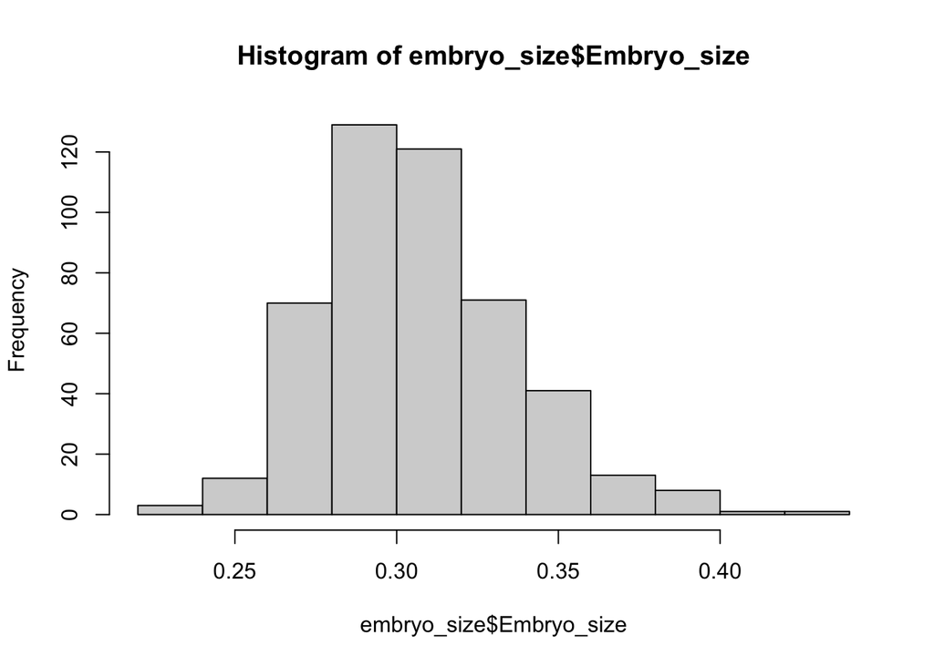

```r
hist(embryo_size$Embryo_size)
```

```r
mean(embryo_size$Embryo_size)
```

```
## [1] 0.3072574
```

```r
sd(embryo_size$Embryo_size)
```

```
## [1] 0.0296581
```

Due to the Normal raw data distribution, we will run a linear mixed effects model and calculate AIC values.

```r
emb_size_lm1 <- lmer(Embryo_size ~ Population + (1 | Aggregation_ID/Capsule_ID), data = embryo_size)

summary(emb_size_lm1)
```

```
## Linear mixed model fit by REML ['lmerMod']
## Formula: Embryo_size ~ Population + (1 | Aggregation_ID/Capsule_ID)
##    Data: embryo_size
##
## REML criterion at convergence: -1987.5
##
## Scaled residuals:
##     Min      1Q  Median      3Q     Max
## -2.7217 -0.6683 -0.0741  0.6098  4.1986
##
## Random effects:
##  Groups                    Name        Variance  Std.Dev.
##  Capsule_ID:Aggregation_ID (Intercept) 9.398e-05 0.009694
##  Aggregation_ID            (Intercept) 2.137e-05 0.004622
##  Residual                              7.134e-04 0.026710
## Number of obs: 470, groups:  Capsule_ID:Aggregation_ID, 45; Aggregation_ID, 10
##
## Fixed effects:
##               Estimate Std. Error t value
## (Intercept)   0.319345   0.004201  76.014
## PopulationCM -0.008678   0.004683  -1.853
## PopulationDB -0.014646   0.004507  -3.249
## PopulationMB -0.015672   0.004741  -3.306
## PopulationRP -0.028398   0.005619  -5.054
##
## Correlation of Fixed Effects:
##             (Intr) PpltCM PpltDB PpltMB
## PopulatinCM -0.696
## PopulatinDB -0.719  0.623
## PopulatinMB -0.699  0.629  0.693
## PopulatinRP -0.518  0.483  0.475  0.491
```

```r
anova(emb_size_lm1)
```

```
## Analysis of Variance Table
##            npar  Sum Sq  Mean Sq F value
## Population    4 0.02078 0.005195  7.2818
```

```r
Anova(emb_size_lm1)
```

```
## Analysis of Deviance Table (Type II Wald chisquare tests)
##
## Response: Embryo_size
##             Chisq Df Pr(>Chisq)
## Population 29.127  4  7.366e-06 ***
## ---
## Signif. codes:  0 '***' 0.001 '**' 0.01 '*' 0.05 '.' 0.1 ' ' 1
```

```r
AIC(emb_size_lm1)
```

```
## [1] -1971.528
```

```r
AICc(emb_size_lm1)
```

```
## [1] -1971.215
```

Assess pairwise comparisons using emmeans and Tukey adjustments

```r
em <- emmeans(emb_size_lm1, "Population", data = embryo_size)
contrast(em, "pairwise", adjust = "Tukey")
```

```
##  contrast estimate      SE  df t.ratio p.value
##  CB - CM   0.00868 0.00479 332   1.813  0.3678
##  CB - DB   0.01465 0.00463 338   3.165  0.0145
##  CB - MB   0.01567 0.00487 336   3.220  0.0122
##  CB - RP   0.02840 0.00569 460   4.995 <0.0001
##  CM - DB   0.00597 0.00410 249   1.457  0.5913
##  CM - MB   0.00699 0.00414 309   1.689  0.4421
##  CM - RP   0.01972 0.00539 399   3.659  0.0026
##  DB - MB   0.00103 0.00366 465   0.280  0.9986
##  DB - RP   0.01375 0.00539 391   2.552  0.0815
##  MB - RP   0.01273 0.00537 415   2.368  0.1263
##
## Degrees-of-freedom method: kenward-roger
## P value adjustment: tukey method for comparing a family of 5 estimates
```

Plot model residuals to assess model fit

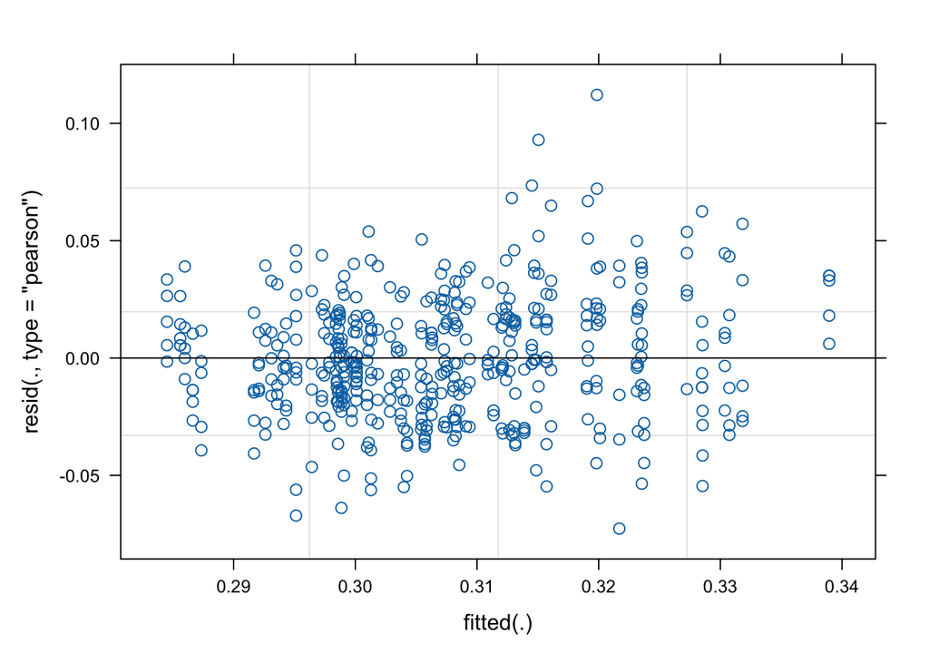

```r
plot(emb_size_lm1)
```